# Mixed Effects Models

### Multilevel Model

\[y_{i} = \alpha_{j[i]} + \beta (floor)_i + \epsilon_{i}\] \[\alpha_j \sim N(\mu_{\alpha}, \sigma_{\alpha}^2)\] \[\epsilon_i \sim N(0, \sigma_y^2)\]

This is a *varying-intercept model with a unit-level predictor*.

- \(y_i\) is the logarithm of the radon measurement in house \(i\).
- \(\alpha_{j[i]}\) is a random effect of county \(j\). It is the mean of the logarithm of radon measurements taken at the basement in all houses in county \(j\).
- \(\beta\) is the average difference between the logarithm of radon measurements taken on the first floor and the logarithm of radon measurements taken at the basement.
- \(\mu_{\alpha}\) is the mean of the logarithm of radon measurements taken at the basement in all houses across all counties.
- \(\sigma_{\alpha}^2\) is the variance between counties.
- \(\sigma_{y}^2\) is the variance within a county.

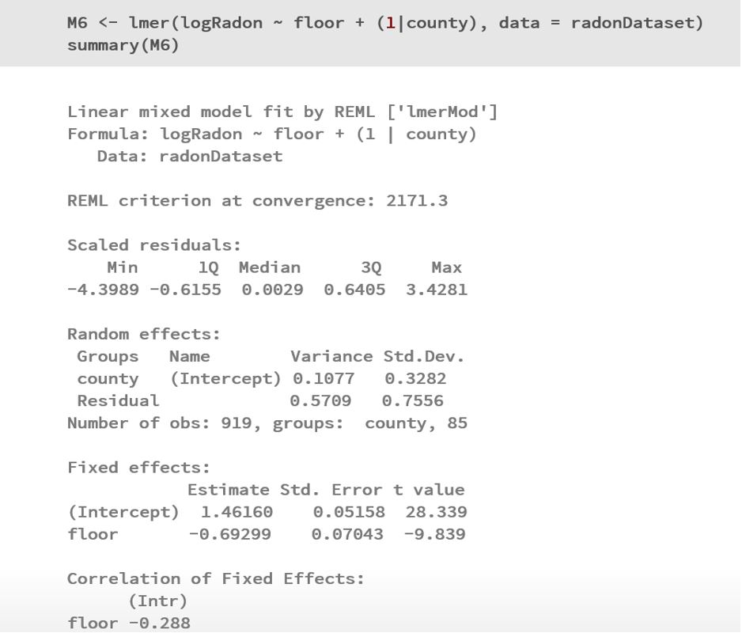

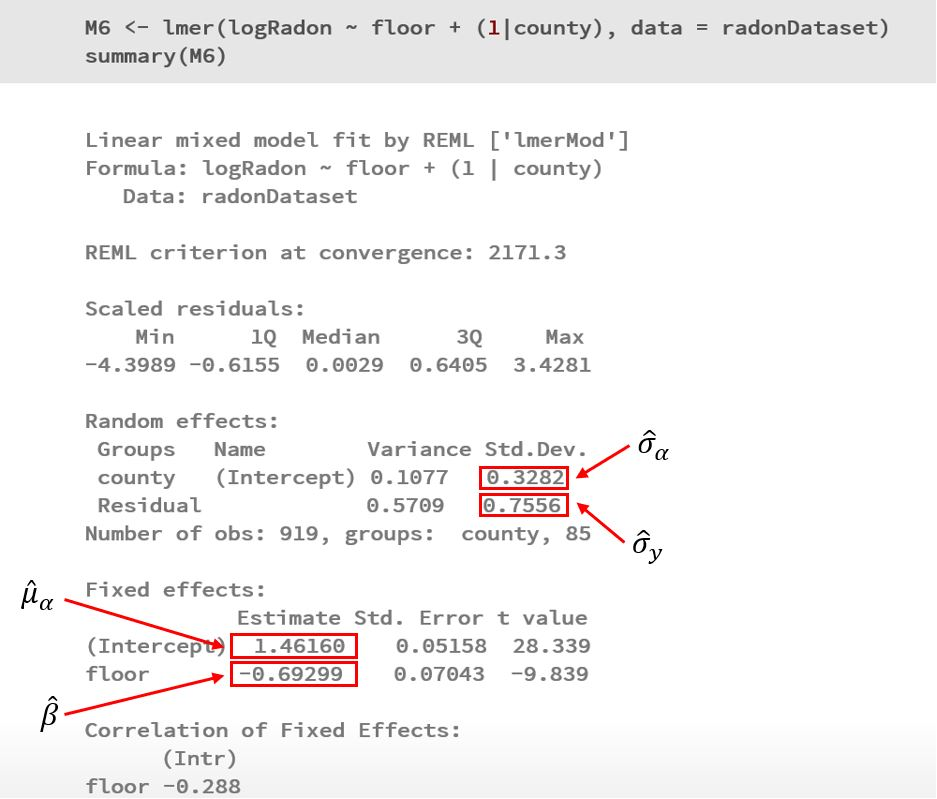

```r
head(coef(M6)$county, 5)
```

```
         (Intercept)      floor
AITKIN     1.1915004 -0.6929937
ANOKA      0.9276468 -0.6929937
BECKER     1.4792143 -0.6929937
BELTRAMI   1.5045012 -0.6929937
BENTON     1.4461503 -0.6929937
```

```r
fixef(M6)
```

```
(Intercept)       floor
  1.4615979  -0.6929937
```

```r
head(ranef(M6)$county, 5)
```

```
         (Intercept)
AITKIN   -0.27009750
ANOKA    -0.53395107
BECKER    0.01761646
BELTRAMI  0.04290331
BENTON   -0.01544759
```

```r
sigmas <- arm::sigma.hat(M6)$sigma
sigmas
```

```
$data
[1] 0.7555892

$county
(Intercept)
  0.3282224
```

```r
icc <- sigmas$county^2/(sigmas$county^2 + sigmas$data^2)
icc
```

```
(Intercept)
  0.1587427
```

Comparing models M3 and M6:

```r
anova(M3, M6)
```

```
Data: radonDataset
Models:
M3: logRadon ~ 1 + (1 | county)
M6: logRadon ~ floor + (1 | county)
   Df    AIC    BIC  logLik deviance  Chisq Chi Df Pr(>Chisq)
M3  3 2261.2 2275.7 -1127.6   2255.2
M6  4 2171.7 2190.9 -1081.8   2163.7 91.587      1  < 2.2e-16 ***
---
Signif. codes:  0 '***' 0.001 '**' 0.01 '*' 0.05 '.' 0.1 ' ' 1
```

### Multilevel Model

\[y_{i} = \alpha_{j[i]} + \beta_{j[i]} (floor)_i + \epsilon_{i}\] \[\alpha_j \sim N(\mu_{\alpha}, \sigma_{\alpha}^2)\] \[\beta_j \sim N(\mu_{\beta}, \sigma_{\beta}^2)\] \[\epsilon_i \sim N(0, \sigma_y^2)\]

This is a *varying-intercept, varying slope model*.

- \(y_i\) is the logarithm of the radon measurement in house \(i\).
- \(\alpha_{j[i]}\) is a random effect of county \(j\). It is the mean of the logarithm of radon measurements taken at the basement in all houses in county \(j\).
- \(\beta_{j[i]}\) is another random effect of county \(j\). It is the average difference between the logarithm of radon measurements taken on the first floor and the logarithm of radon measurements taken at the basement in all houses in county \(j\).
- \(\mu_{\alpha}\) is the mean of the logarithm of radon measurements taken at the basement in all houses across all counties.
- \(\mu_{\beta}\) is the mean of the difference between the logarithm of radon measurements taken on the first floor and the logarithm of radon measurements taken at the basement in all houses across all counties.
- \(\sigma_{\alpha}^2\) and \(\sigma_{\beta}^2\) are variances between counties.
- \(\sigma_{y}^2\) is the variance within a county.

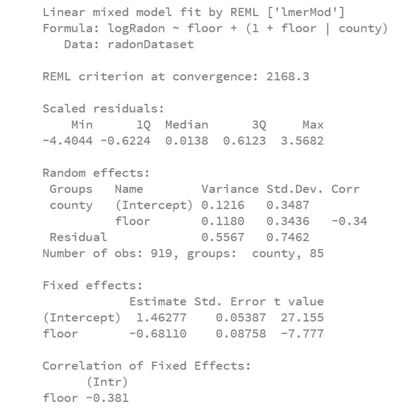

```r
M7 <- lmer(logRadon ~ floor + (1 + floor|county), data = radonDataset)
summary(M7)
```

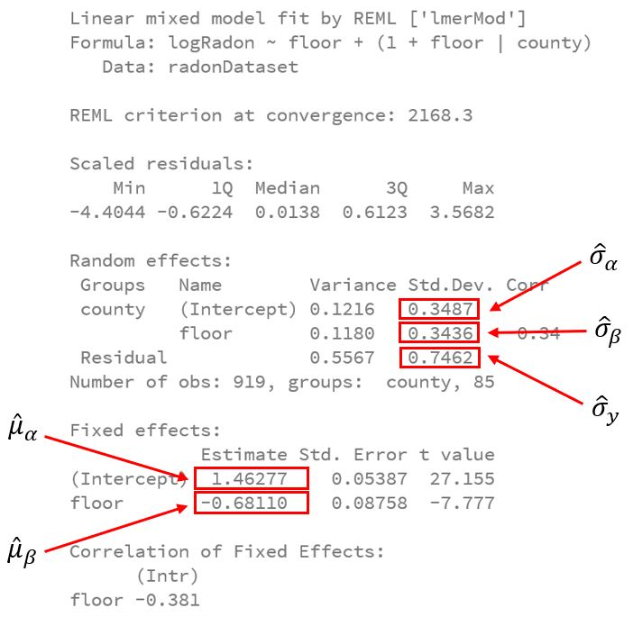

```r
M7 <- lmer(logRadon ~ floor + (1 + floor|county), data = radonDataset)
summary(M7)
```

```r
head(coef(M7)$county, 5)
```

```
         (Intercept)      floor
AITKIN     1.1445556 -0.5406955
ANOKA      0.9333772 -0.7708832
BECKER     1.4716933 -0.6688825
BELTRAMI   1.5354221 -0.7525325
BENTON     1.4270472 -0.6206849
```

```r
fixef(M7)
```

```
(Intercept)       floor
  1.4627698  -0.6810962
```

```r
head(ranef(M7)$county, 5)
```

```
          (Intercept)       floor
AITKIN   -0.318214256  0.14040071
ANOKA    -0.529392673 -0.08978708
BECKER    0.008923442  0.01221364
BELTRAMI  0.072652285 -0.07143636
BENTON   -0.035722607  0.06041130
```

Comparing models M6 and M7:

```r
anova(M6, M7)
```

```
Data: radonDataset
Models:
M6: logRadon ~ floor + (1 | county)
M7: logRadon ~ floor + (1 + floor | county)
   Df    AIC    BIC  logLik deviance  Chisq Chi Df Pr(>Chisq)
M6  4 2171.7 2190.9 -1081.8   2163.7
M7  6 2173.1 2202.1 -1080.5   2161.1 2.5418      2     0.2806
```